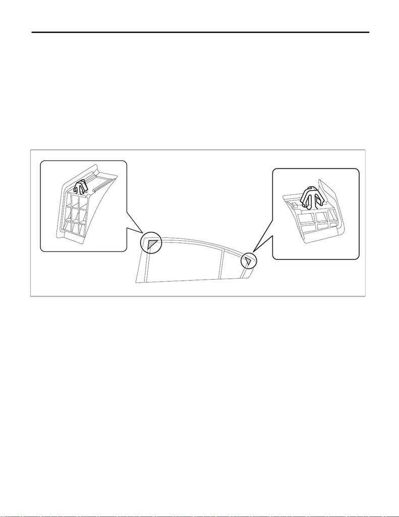

EB-34

Rear Door

EXTERIOR BODY PANELS

6. Rear Door

A: REMOVAL

1. REAR DOOR PANEL

1) Disconnect the ground cable from battery. <Ref. to NT-5, BATTERY, NOTE, Note.>

NOTE:

For models other than STI model, disconnect the ground terminal from battery sensor.

2) Remove the trim panel - rear door. <Ref. to EI-57, REAR DOOR, REMOVAL, Door Trim.>

3) Remove the sealing cover - rear door. <Ref. to EB-41, REMOVAL, Rear Sealing Cover.>

4) Remove the cover B pillar - rear door INN and the cover C pillar - rear door INN.

CAUTION:

Always replace with a new part, because engagement of the claw weakens.

5) Remove the rear door speaker assembly. <Ref. to ET-11, REMOVAL, Rear Speaker.>

6) Remove the sash COMPL - rear partition and the glass assembly - rear door. <Ref. to GW-34, REMOVAL,

Rear Door Glass.>

7) Remove the regulator - rear. <Ref. to GW-37, REMOVAL, Rear Regulator and Motor Assembly.>

8) Remove the latch and actuator assembly - rear. <Ref. to SL-45, REMOVAL, Rear Door Latch and Door

Lock Actuator Assembly.>

9) Remove the cover - handle rear outer. <Ref. to SL-41, REMOVAL, Rear Outer Handle.>

10) Remove the weather strip - rear door. <Ref. to EB-58, REPLACEMENT, Weather Strip.>

EB-00784

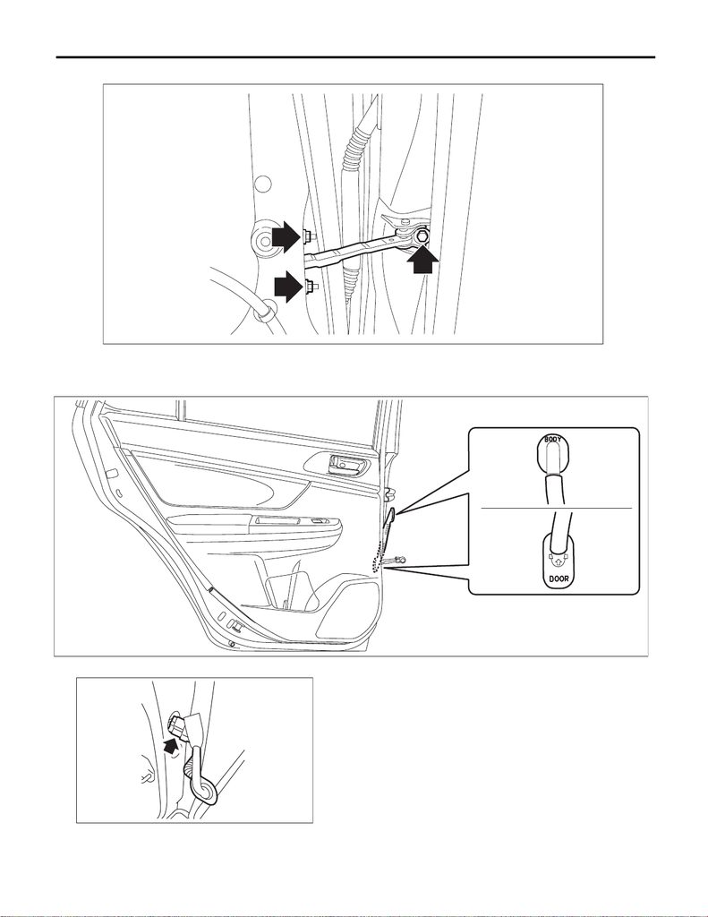

EB-35

Rear Door

EXTERIOR BODY PANELS

11) Remove the bolts and nuts, and then detach the checker assembly - rear door.

12) Remove the trim panel - center pillar LWR. <Ref. to EI-81, REMOVAL, Lower Inner Trim.>

13) Disconnect the rear door harness connectors.

(1) Remove the grommet and pull out the rear door harness connector from inside the center pillar.

(2) Disconnect the rear door harness connectors.

EB-00892

EB-00972

EB-00284

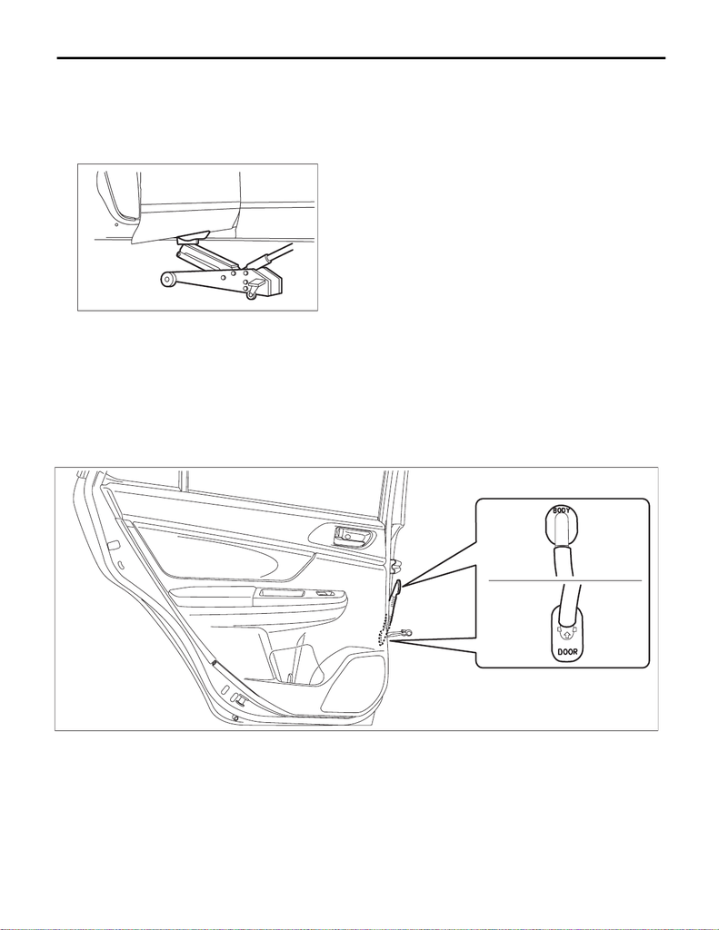

EB-36

Rear Door

EXTERIOR BODY PANELS

14) Before removing the panel assembly - rear door, make the following preparations.

CAUTION:

Do not excessively lift the panel assembly - rear door with the floor jack. The door hinges may be

damaged.

(1) Put a wooden block on a floor jack and place the jack under the panel assembly - rear door.

(2) Support the panel assembly - rear door with the jack to protect it from damage.

15) Remove the door-side bolts for the upper hinge - rear door and the lower hinge - rear door to remove the

panel assembly - rear door.

CAUTION:

The panel assembly - rear door is heavy. When removing and installing it, always work in a team of

two or more persons.

2. REAR DOOR HINGE

1) Remove the trim panel - center pillar LWR. <Ref. to EI-81, REMOVAL, Lower Inner Trim.>

2) Disconnect the rear door harness connectors.

(1) Remove the grommet and pull out the rear door harness connector from inside the center pillar.

EB-00750

EB-00972

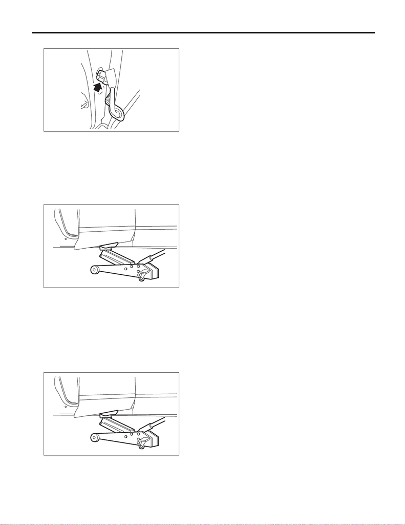

EB-37

Rear Door

EXTERIOR BODY PANELS

(2) Disconnect the rear door harness connectors.

3) Before removing the panel assembly - rear door, make the following preparations.

CAUTION:

(1) Put a wooden block on a floor jack and place the jack under the panel assembly - rear door.

(2) Support the panel assembly - rear door with the jack to protect it from damage.

4) Remove the bolts on the side of the panel assembly - rear door of the upper hinge - rear door or the lower

hinge - rear door.

CAUTION:

Do not remove the upper hinge - rear door and the lower hinge - rear door at the same time.

5) Remove the hinge - rear door from the vehicle.

B: INSTALLATION

1. REAR DOOR PANEL

1) Put a wooden block and the like on a jack and place the panel assembly - rear door on it.

EB-00284

EB-00750

EB-00750

[figure not shown]

EB-38

Rear Door

EXTERIOR BODY PANELS

2) Adjust the height by the jack, and temporarily install the panel assembly - rear door to the upper hinge -

rear door and the lower hinge - rear door.

NOTE:

• When installing the panel assembly - rear door, make sure that a uniform clearance is created around the

panel.

• Perform installation while paying attention to the assembly direction of the grommet.

3) Adjust the clearance around the panel assembly - rear door. <Ref. to EB-39, ADJUSTMENT, Rear Door.>

4) Tighten the mounting bolts of the panel assembly - rear door to the specified torque.

Tightening torque:

25 N·m (2.5 kgf-m, 18.4 ft-lb)

5) Tighten the bolts and nuts of the checker assembly - rear door.

Tightening torque:

Refer to “COMPONENT” of “General Description”. <Ref. to EB-5, REAR DOOR, COMPONENT, Gen-

eral Description.>

6) Connect the door harness connector, and install the trim panel - center pillar LWR. <Ref. to EI-84, IN-

STALLATION, Lower Inner Trim.>

7) Install door internal parts in the reverse order of removal.

• Weather strip - rear door

• Handle - door outer

Tightening torque:

7.5 N·m (0.8 kgf-m, 5.5 ft-lb)

• Latch & actuator ASSY - rear

Tightening torque:

6.5 N·m (0.7 kgf-m, 4.8 ft-lb)

• Regulator & motor assembly - rear for the rear door

Tightening torque:

7.5 N·m (0.8 kgf-m, 5.5 ft-lb)

• Sash COMPL - rear partition, and glass assembly - rear door

Tightening torque:

7.5 N·m (0.8 kgf-m, 5.5 ft-lb)

8) Install the cover B pillar - rear door INN and the cover C pillar - rear door INN.

CAUTION:

Always replace with a new part, because engagement of the claw weakens.

9) Install the rear door speaker assembly.

10) Install the sealing cover. <Ref. to EB-41, INSTALLATION, Rear Sealing Cover.>

11) Install the trim panel - rear door. <Ref. to EI-58, INSTALLATION, Door Trim.>

12) Connect the battery ground terminal. <Ref. to NT-5, BATTERY, NOTE, Note.>

NOTE:

For models other than STI model, connect the ground terminal to battery sensor.

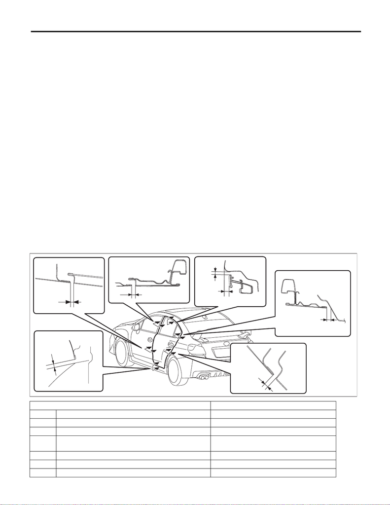

EB-39

Rear Door

EXTERIOR BODY PANELS

2. REAR DOOR HINGE

1) Apply grease to the sliding area of door hinges, and install to vehicle.

Tightening torque:

30 N·m (3.1 kgf-m, 22.1 ft-lb)

2) Adjust the height by the jack, and temporarily install the panel assembly - rear door to the upper hinge -

rear door and the lower hinge - rear door.

NOTE:

When installing the panel assembly - rear door, make sure that a uniform clearance is created around the

panel.

3) Adjust the clearance around the panel assembly - rear door. <Ref. to EB-39, ADJUSTMENT, Rear Door.>

NOTE:

When installing the panel assembly - rear door, make sure that a uniform clearance is created around the

panel.

4) Tighten the bolts of the panel assembly - rear door to the specified torque.

Tightening torque:

25 N·m (2.5 kgf-m, 18.4 ft-lb)

5) Connect the door harness connector, and install the trim panel - center pillar LWR. <Ref. to EI-84, IN-

STALLATION, Lower Inner Trim.>

6) Tighten the bolts on the vehicle side of the checker assembly - rear door.

Tightening torque:

Refer to “COMPONENT” of “General Description”. <Ref. to EB-5, REAR DOOR, COMPONENT, Gen-

eral Description.>

C: ADJUSTMENT

Adjust the clearance around the panel assembly - rear door as follows.

Part Standard

A Panel assembly - front door to Panel assembly - rear door 4.5±1.0 mm (0.18±0.04 in)

B Front door sash to Rear door sash 5.5+1.5, -1.0 mm (0.22+0.06, -0.04 in)

C Panel - side outer to Rear door sash 5.1+1.5, -1.0 mm (0.20+0.06, -0.04 in)

D Surface level gap between Panel - side outer to Rear door

sash

6.6±1.5 mm (0.26±0.06 in)

E Rear door sash and Panel - side outer 5.5+1.5, -1.0 mm (0.22+0.06, -0.04 in)

F Panel assembly - rear door to Panel - side outer 4.1±1.0 mm (0.16±0.04 in)

G Panel assembly - rear door to Spoiler assembly - side 6.0±1.5 mm (0.24±0.06 in)

EB-00973

G

A

B

C

D

E

F

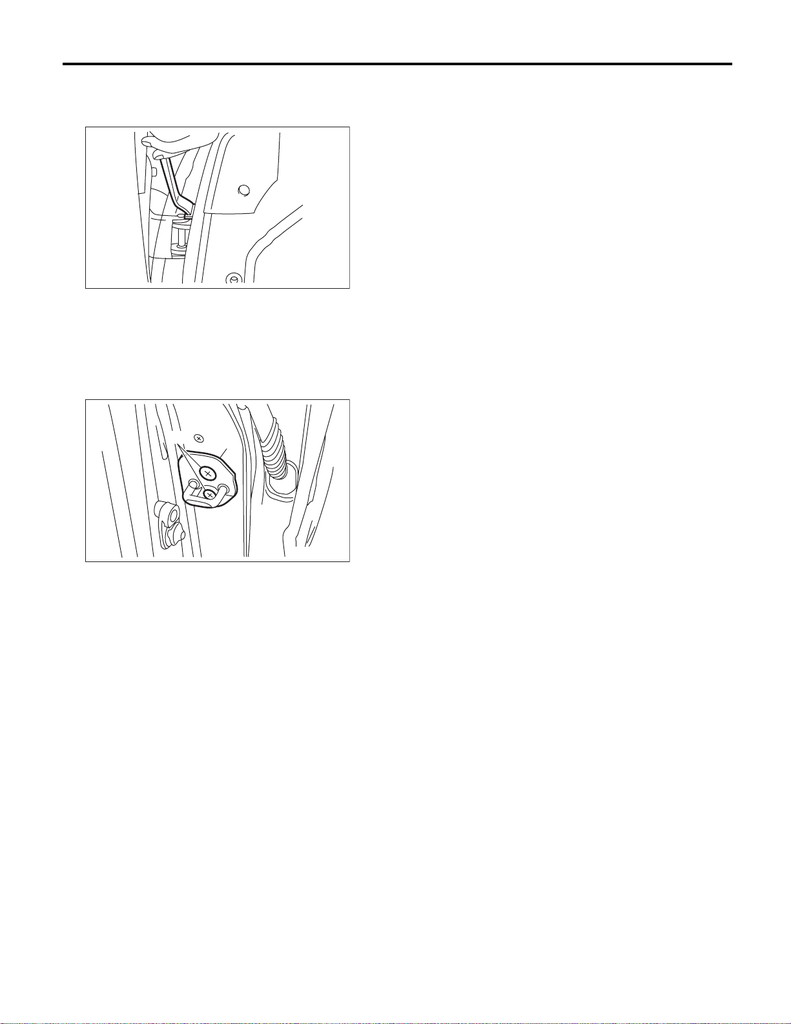

EB-40

Rear Door

EXTERIOR BODY PANELS

1) Adjust the vertical and horizontal positions of the panel assembly - rear door.

(1) Loosen the body side bolts of the upper hinge - rear door and the lower hinge - rear door.

(2) Adjust the vertical and horizontal clearance of the panel assembly - rear door.

2) Adjust the surface level gap between the panel assembly - rear door and the body.

CAUTION:

Do not use an impact wrench. Welding area on the striker nut plate is easily broken.

(1) Loosen the screws (A).

(2) Tap the striker - rear door (B) using a plastic hammer to adjust the surface level gap between the rear

end of the panel assembly - rear door and the rear quarter.

EB-00015

EB-00017

(B)

(A)